# PROPOSAL DCD_Customer Churn

## PROPOSAL DCD

### CHURN RATE PREDICTION

[figure not shown]

### 1 Background

In the highly competitive business landscape of today, maintaining a loyal customer base is paramount for sustained growth and profitability. The ability to predict customer churn, the rate at which customers discontinue their association with a company, plays a crucial role in understanding customer behavior and implementing effective retention strategies.

"To predict customer's churn" is a fundamental aspect of churn rate prediction. It involves employing advanced data analytics, machine learning algorithms, and predictive modeling techniques to anticipate which customers are likely to churn in the future. By identifying potential churners early on, businesses can proactively devise tailored strategies to retain these customers and prevent revenue loss.

The underlying premise behind churn rate prediction is that understanding why customers churn empowers businesses to address root causes effectively. Customer churn can be attributed to various factors, such as poor customer service, product dissatisfaction, pricing concerns, or competitive offerings. Therefore, by analyzing historical customer data, including transactional behavior, interaction patterns, and feedback, businesses can uncover patterns and trends that contribute to customer attrition.

Accurate churn rate prediction offers numerous benefits for businesses, including:

- Enhanced Customer Retention: By identifying at-risk customers, businesses can design personalized interventions to meet their specific needs and preferences, fostering loyalty and prolonging customer lifetime value.
- Cost Optimization: Retaining existing customers is often more cost-effective than acquiring new ones. Predicting churn allows businesses to allocate resources efficiently, focusing on high-value customers who are more likely to leave.
- Data-Driven Decision Making: Churn prediction empowers businesses to make data-driven decisions, as they gain insights into customer behavior and can prioritize actions based on quantifiable risk.
- Competitive Advantage: Organizations that can accurately predict and manage churn gain a competitive edge by consistently offering exceptional customer experiences and preventing customer loss to rivals.
- Product and Service Improvements: Churn prediction also highlights weaknesses in products or services, enabling businesses to make necessary improvements and enhance customer satisfaction.

In conclusion, "To predict customer's churn" is a vital business endeavor that allows companies to leverage data analytics and predictive modeling to foresee and mitigate customer attrition. By understanding the reasons behind churn and implementing proactive retention strategies, businesses can foster customer loyalty, optimize costs, and maintain a competitive edge in the market.

### 2 Problem Statement

Customer churn is one of the most critical metrics for a growing business to evaluate, as it directly impacts the competitiveness of the service provider and provides essential insights into its customer retention strategies. However, accurately predicting customer churn remains a significant challenge for businesses, hindering their ability to proactively address attrition and optimize customer retention efforts.

Reference studies have shown that customer churn can lead to substantial revenue losses and increased customer acquisition costs for service providers. Understanding the underlying factors driving churn is crucial to devise effective retention strategies and maintain a competitive edge in the market. Existing literature highlights the significance of churn rate prediction in enabling businesses to anticipate customer defection and take timely measures to retain valuable customers.

Despite the abundance of data generated through customer interactions, transactional behavior, and feedback, businesses often struggle to harness this data effectively to predict churn accurately. Traditional rule-based methods or manual analysis fail to capture complex patterns and correlations present in large-scale datasets, resulting in suboptimal churn prediction performance.

Furthermore, the dynamic nature of customer behavior and market trends introduces additional complexity, necessitating the application of advanced data analytics and machine learning techniques to effectively model and predict churn.

To address these challenges, there is a clear need for a robust churn rate prediction solution that leverages cutting-edge data science methodologies and predictive modeling. By combining large-scale data processing, feature engineering, and sophisticated machine learning algorithms, businesses can gain actionable insights into customer churn behavior and implement personalized retention strategies to mitigate attrition.

Therefore, the objective of this project is to develop a comprehensive churn rate prediction system that empowers businesses to:

- Accurately forecast customer churn based on historical data and customer attributes.
- Identify the key drivers and factors contributing to customer defection, providing valuable insights for retention strategies.
- Optimize resource allocation and prioritize efforts to focus on high-value customers at risk of churning.
- Continuously update and improve the churn prediction model to adapt to evolving customer behaviors and market dynamics.
- Enhance customer retention rates, leading to increased profitability and improved competitiveness for the service provider.

By addressing the challenge of churn rate prediction, this project aims to equip businesses with the necessary tools and knowledge to better understand their customer base, boost customer retention efforts, and foster long-term growth and success in an increasingly competitive market.

### 3 Problem Scope

Data used are from the IBM Watson Repository - Sample Datasets for Customer Retention Programs, where each rows represents the customers, and each columns represents the customer’s attribute. Such as :

- **The target** - The target columns is 'Churn'. It represents the customers who retained (0) and left within the last month (1).
- **The service types** - Represents what type of services each customer has signed up for, it contained : phone, multiple lines, internet, online security, online backup, device protection, tech support, and streaming TV and movies.
- **The customer account information** - Represents how long the customer's been subscibed to, this contained : contract, payment method, paperless billing, monthly charges, and total charges.
- **The demographic info about customers** - Contains additional info for the customers, such as : gender, senior citizenship status, and whether if they have partners and dependents.

Coloumns Descriptions :

- customerID - Customer's ID.
- gender - Customer's gender.
- SeniorCitizen - Whether the customer is a senior citizen or not.
- Partner - Whether the customer has a partner or not.
- Dependents - Whether the customer has dependents or not.
- tenure - How long has the customer subscribed in months.
- PhoneService - Whether the customer has a phone service or not.
- MultipleLines - Whether the customer has multiple lines or not.
- InternetService - Customer’s internet service provider status.
- OnlineSecurity - Whether the customer has online security or not.
- OnlineBackup - Whether the customer has online backup or not.
- DeviceProtection - Whether the customer has device protection or not.
- TechSupport - Whether the customer has tech support or not.
- StreamingTV - Whether the customer has streaming TV or not.
- StreamingMovies - Whether the customer has streaming movies or not.
- Contract - The customer's contract term.
- PaperlessBilling - Whether the customer has paperless billing or not.
- PaymentMethod - The customer’s payment method.
- MonthlyCharges - The amount charged to the customer (monthly).
- TotalCharges - The total amount charged to the customer.
- Churn - Whether the customer churned or not churned.

### 4 Project Idea

The goal of this project are to build the best Machine Learning model to predict the churned or not churned customers, as well as giving some insight regarding the behaviors of said customers in order to help retain the attrition rate.

### 5 Output

The output of this project is a Model Deployment with FLASK and a Tableu dashboard that displays Exploratory Data to show Client Profile, Churn Profile and Churned Report.

### 6 Business Impact

1. Increase Customer Retention: By accurately predicting churn, the company can identify high-value customers at risk of leaving and take proactive measures to retain them. This could lead to increased customer loyalty and a higher customer retention rate.
2. Improved Customer Segmentation: Through churn rate prediction, the business can categorize customers based on their likelihood to churn. This allows for a targeted approach in tailoring marketing strategies and services to different customer segments, ultimately boosting customer satisfaction and engagement.
3. Enhanced Customer Experience: Offering better services to customers identified as potential churners helps in addressing their pain points and concerns. This focus on customer satisfaction can lead to improved overall customer experience, resulting in higher customer loyalty and advocacy.
4. Continuous Feedback Loop: Regularly seeking feedback and suggestions from customers can provide valuable insights into their needs and expectations. This feedback loop can facilitate product/service improvements and foster stronger relationships with customers, ultimately reducing churn and increasing customer satisfaction.
5. Competitive Edge: By offering incentives and rewards to retain customers, the company can stay competitive with rivals in the market. This strategy can differentiate the business, attract new customers, and persuade existing customers to remain loyal amidst competitors' offerings.
6. Increased Revenue: Minimizing churn directly impacts the company's bottom line. Retaining existing customers is more cost-effective than acquiring new ones, and a reduction in churn can lead to increased revenue and improved long-term financial stability.
7. Data-Driven Decision Making: The churn rate prediction project requires analyzing customer data and behavior patterns. This promotes a data-driven decision-making culture within the organization, enabling better strategic planning and resource allocation.
8. Sustainable Growth: A focus on customer retention through churn rate prediction fosters sustainable business growth. By maintaining a loyal customer base, the company can build a stable revenue stream and create a foundation for future expansion and success.

In summary, the churn rate prediction project can significantly impact the business by improving customer retention, enhancing the customer experience, and fostering data-driven decision-making. These outcomes lead to increased revenue, a competitive advantage, and sustainable growth for the company.

### 7 Project Model Prediction Flow

[figure not shown]

#### SECTION 1 - PREPROCESSING AND EXPLORATORY DATA ANALYSIS

## OVERVIEW

> In this section, we want to further examine the data by checking all the necessary info, check for the missing values and thus cleaning the data before the EDA process. So that it may correctly visualized and translated in the EDA process. We start this by loading all the packages needed and importing the data.

### IMPORTING LIBRARIES

```python
import numpy as np
import pandas as pd
import matplotlib.pyplot as plt
import seaborn as sns

import scipy.stats as ss
from scipy.stats import anderson, chi2_contingency

plt.style.use('ggplot')

import warnings
warnings.filterwarnings('ignore')
```

### LOAD DATA

```python
df = pd.read_csv('Telco-Customer-Churn.csv')
```

```python
df.head()
```

|  | customerID | gender | SeniorCitizen | Partner | Dependents | tenure | PhoneService | MultipleLines | InternetService | OnlineSecurity | ... | DeviceProtection | TechSupport | StreamingTV | StreamingMovies | Contract | PaperlessBilling | PaymentMethod | MonthlyCharges | TotalCharges | Churn |
| --- | --- | --- | --- | --- | --- | --- | --- | --- | --- | --- | --- | --- | --- | --- | --- | --- | --- | --- | --- | --- | --- |
| 0 | 7590-VHVEG | Female | 0 | Yes | No | 1 | No | No phone service | DSL | No | ... | No | No | No | No | Month-to-month | Yes | Electronic check | 29.85 | 29.85 | No |
| 1 | 5575-GNVDE | Male | 0 | No | No | 34 | Yes | No | DSL | Yes | ... | Yes | No | No | No | One year | No | Mailed check | 56.95 | 1889.5 | No |
| 2 | 3668-QPYBK | Male | 0 | No | No | 2 | Yes | No | DSL | Yes | ... | No | No | No | No | Month-to-month | Yes | Mailed check | 53.85 | 108.15 | Yes |
| 3 | 7795-CFOCW | Male | 0 | No | No | 45 | No | No phone service | DSL | Yes | ... | Yes | Yes | No | No | One year | No | Bank transfer (automatic) | 42.30 | 1840.75 | No |
| 4 | 9237-HQITU | Female | 0 | No | No | 2 | Yes | No | Fiber optic | No | ... | No | No | No | No | Month-to-month | Yes | Electronic check | 70.70 | 151.65 | Yes |

5 rows × 21 columns

```python
df.tail()
```

|  | customerID | gender | SeniorCitizen | Partner | Dependents | tenure | PhoneService | MultipleLines | InternetService | OnlineSecurity | ... | DeviceProtection | TechSupport | StreamingTV | StreamingMovies | Contract | PaperlessBilling | PaymentMethod | MonthlyCharges | TotalCharges | Churn |
| --- | --- | --- | --- | --- | --- | --- | --- | --- | --- | --- | --- | --- | --- | --- | --- | --- | --- | --- | --- | --- | --- |
| 7038 | 6840-RESVB | Male | 0 | Yes | Yes | 24 | Yes | Yes | DSL | Yes | ... | Yes | Yes | Yes | Yes | One year | Yes | Mailed check | 84.80 | 1990.5 | No |
| 7039 | 2234-XADUH | Female | 0 | Yes | Yes | 72 | Yes | Yes | Fiber optic | No | ... | Yes | No | Yes | Yes | One year | Yes | Credit card (automatic) | 103.20 | 7362.9 | No |
| 7040 | 4801-JZAZL | Female | 0 | Yes | Yes | 11 | No | No phone service | DSL | Yes | ... | No | No | No | No | Month-to-month | Yes | Electronic check | 29.60 | 346.45 | No |
| 7041 | 8361-LTMKD | Male | 1 | Yes | No | 4 | Yes | Yes | Fiber optic | No | ... | No | No | No | No | Month-to-month | Yes | Mailed check | 74.40 | 306.6 | Yes |
| 7042 | 3186-AJIEK | Male | 0 | No | No | 66 | Yes | No | Fiber optic | Yes | ... | Yes | Yes | Yes | Yes | Two year | Yes | Bank transfer (automatic) | 105.65 | 6844.5 | No |

5 rows × 21 columns

> We've load the data and, check the head and tail of the data, for the next process, I found that it's a little unpleasant that there are some features name that are in a different typing than the other features. Let's try to make some changes in those feature's column names.

```python
df = df.rename(columns= {'tenure' : 'Tenure',
                         'gender' : 'Gender'})
```

> Then, after we've done renaming said columns / features, we need to check the information within our data so that we gained more understanding in this data. Especially we need to carefully examine the data type so that the data type matches correctly with the column / features name.

```python
df.info()
```

```
<class 'pandas.core.frame.DataFrame'>
RangeIndex: 7043 entries, 0 to 7042
Data columns (total 21 columns):
 #   Column            Non-Null Count  Dtype
---  ------            --------------  -----
 0   customerID        7043 non-null   object
 1   Gender            7043 non-null   object
 2   SeniorCitizen     7043 non-null   int64
 3   Partner           7043 non-null   object
 4   Dependents        7043 non-null   object
 5   Tenure            7043 non-null   int64
 6   PhoneService      7043 non-null   object
 7   MultipleLines     7043 non-null   object
 8   InternetService   7043 non-null   object
 9   OnlineSecurity    7043 non-null   object
 10  OnlineBackup      7043 non-null   object
 11  DeviceProtection  7043 non-null   object
 12  TechSupport       7043 non-null   object
 13  StreamingTV       7043 non-null   object
 14  StreamingMovies   7043 non-null   object
 15  Contract          7043 non-null   object
 16  PaperlessBilling  7043 non-null   object
 17  PaymentMethod     7043 non-null   object
 18  MonthlyCharges    7043 non-null   float64
 19  TotalCharges      7043 non-null   object
 20  Churn             7043 non-null   object
dtypes: float64(1), int64(2), object(18)
memory usage: 1.1+ MB
```

> With some inspection, we can carefully see that the SeniorCitizen has an 'int' data type, I'd like to change this to an 'object' data type, so that all this features has similar attributes as the other features. In the other hand, TotalCharges features has an 'object' type data, it should be a float, because as in the description mentioned above, the customer's TotalCharges is an accumulated of it's MonthlyCharges.

> But for now we just ignore it and proceed to the data description, so that we can see more information about the features. As for the above problem, we will handle it in the preprocessing part.

```python
df.describe()
```

|  | SeniorCitizen | Tenure | MonthlyCharges |
| --- | --- | --- | --- |
| count | 7043.000000 | 7043.000000 | 7043.000000 |
| mean | 0.162147 | 32.371149 | 64.761692 |
| std | 0.368612 | 24.559481 | 30.090047 |
| min | 0.000000 | 0.000000 | 18.250000 |
| 25% | 0.000000 | 9.000000 | 35.500000 |
| 50% | 0.000000 | 29.000000 | 70.350000 |
| 75% | 0.000000 | 55.000000 | 89.850000 |
| max | 1.000000 | 72.000000 | 118.750000 |

```python
df.describe(include='object').T
```

|  | count | unique | top | freq |
| --- | --- | --- | --- | --- |
| customerID | 7043 | 7043 | 7590-VHVEG | 1 |
| Gender | 7043 | 2 | Male | 3555 |
| Partner | 7043 | 2 | No | 3641 |
| Dependents | 7043 | 2 | No | 4933 |
| PhoneService | 7043 | 2 | Yes | 6361 |
| MultipleLines | 7043 | 3 | No | 3390 |
| InternetService | 7043 | 3 | Fiber optic | 3096 |
| OnlineSecurity | 7043 | 3 | No | 3498 |
| OnlineBackup | 7043 | 3 | No | 3088 |
| DeviceProtection | 7043 | 3 | No | 3095 |
| TechSupport | 7043 | 3 | No | 3473 |
| StreamingTV | 7043 | 3 | No | 2810 |
| StreamingMovies | 7043 | 3 | No | 2785 |
| Contract | 7043 | 3 | Month-to-month | 3875 |
| PaperlessBilling | 7043 | 2 | Yes | 4171 |
| PaymentMethod | 7043 | 4 | Electronic check | 2365 |
| TotalCharges | 7043 | 6531 |  | 11 |
| Churn | 7043 | 2 | No | 5174 |

> Now that we gained enough information this data overview, will start further handling the necessary problem in this preprocessing part below.

### PREPROCESSING

> As mentioned above, in this part we'll try to fix the data type of the SeniorCitizen and TotalCharges features. But first let's call the said features and check the data types and null values.

```python
pd.DataFrame({'features' : df[['SeniorCitizen', 'TotalCharges']].columns,
              'Data Type' : df[['SeniorCitizen', 'TotalCharges']].dtypes,
              'Null Values' : df[['SeniorCitizen', 'TotalCharges']].isna().sum()}).reset_index(drop = True)
```

|  | features | Data Type | Null Values |
| --- | --- | --- | --- |
| 0 | SeniorCitizen | int64 | 0 |
| 1 | TotalCharges | object | 0 |

> Now, let's try to fix it one by one starting from the SeniorCitizen feature. As we can see, this feature is having an 'int' type. Although in later part especially in building the Machine Learning Models we would have to do some Labelling, for now, I personally would like to change it to an 'object' type. Therefore this feature / column has the same type as the other categorical features (being 'Yes' and 'No').

```python
df['SeniorCitizen'].replace({0: 'No', 1: 'Yes'}, inplace = True)
```

> We've done the change for this feature, let's check it and continue to the next feature below.

```python
pd.DataFrame({'features' : df[['SeniorCitizen', 'TotalCharges']].columns,
              'Data Type' : df[['SeniorCitizen', 'TotalCharges']].dtypes,
              'Null Values' : df[['SeniorCitizen', 'TotalCharges']].isna().sum()}).reset_index(drop = True)
```

|  | features | Data Type | Null Values |
| --- | --- | --- | --- |
| 0 | SeniorCitizen | object | 0 |
| 1 | TotalCharges | object | 0 |

> Now we want to address the TotalCharges feature, we need to see why it could not be set as float in the first place. Below I'll try to locate the error in this column and we might see why this happened.

```python
error_idx=[]

for idx,col in enumerate(df['TotalCharges']):
    try:
        float(col)
    except:
        error_idx.append(idx)
```

```python
df.loc[error_idx]
```

|  | customerID | Gender | SeniorCitizen | Partner | Dependents | Tenure | PhoneService | MultipleLines | InternetService | OnlineSecurity | ... | DeviceProtection | TechSupport | StreamingTV | StreamingMovies | Contract | PaperlessBilling | PaymentMethod | MonthlyCharges | TotalCharges | Churn |
| --- | --- | --- | --- | --- | --- | --- | --- | --- | --- | --- | --- | --- | --- | --- | --- | --- | --- | --- | --- | --- | --- |
| 488 | 4472-LVYGI | Female | No | Yes | Yes | 0 | No | No phone service | DSL | Yes | ... | Yes | Yes | Yes | No | Two year | Yes | Bank transfer (automatic) | 52.55 |  | No |
| 753 | 3115-CZMZD | Male | No | No | Yes | 0 | Yes | No | No | No internet service | ... | No internet service | No internet service | No internet service | No internet service | Two year | No | Mailed check | 20.25 |  | No |
| 936 | 5709-LVOEQ | Female | No | Yes | Yes | 0 | Yes | No | DSL | Yes | ... | Yes | No | Yes | Yes | Two year | No | Mailed check | 80.85 |  | No |
| 1082 | 4367-NUYAO | Male | No | Yes | Yes | 0 | Yes | Yes | No | No internet service | ... | No internet service | No internet service | No internet service | No internet service | Two year | No | Mailed check | 25.75 |  | No |
| 1340 | 1371-DWPAZ | Female | No | Yes | Yes | 0 | No | No phone service | DSL | Yes | ... | Yes | Yes | Yes | No | Two year | No | Credit card (automatic) | 56.05 |  | No |
| 3331 | 7644-OMVMY | Male | No | Yes | Yes | 0 | Yes | No | No | No internet service | ... | No internet service | No internet service | No internet service | No internet service | Two year | No | Mailed check | 19.85 |  | No |
| 3826 | 3213-VVOLG | Male | No | Yes | Yes | 0 | Yes | Yes | No | No internet service | ... | No internet service | No internet service | No internet service | No internet service | Two year | No | Mailed check | 25.35 |  | No |
| 4380 | 2520-SGTTA | Female | No | Yes | Yes | 0 | Yes | No | No | No internet service | ... | No internet service | No internet service | No internet service | No internet service | Two year | No | Mailed check | 20.00 |  | No |
| 5218 | 2923-ARZLG | Male | No | Yes | Yes | 0 | Yes | No | No | No internet service | ... | No internet service | No internet service | No internet service | No internet service | One year | Yes | Mailed check | 19.70 |  | No |
| 6670 | 4075-WKNIU | Female | No | Yes | Yes | 0 | Yes | Yes | DSL | No | ... | Yes | Yes | Yes | No | Two year | No | Mailed check | 73.35 |  | No |
| 6754 | 2775-SEFEE | Male | No | No | Yes | 0 | Yes | Yes | DSL | Yes | ... | No | Yes | No | No | Two year | Yes | Bank transfer (automatic) | 61.90 |  | No |

11 rows × 21 columns

> As we can see above, it would seems that there are 11 row within the TotalCharges feature with (' ') string space character. These rows were not identified as Null, this might be caused by the (' ') string space character, while it should be Null values. So below, we'll change the data type to float and see if this problem resolves.

```python
df['TotalCharges'] = pd.to_numeric(df['TotalCharges'], errors='coerce')
```

> Let's check the data type again, and see if this problem has been solved.

```python
pd.DataFrame({'features' : df[['SeniorCitizen', 'TotalCharges']].columns,
              'Data Type' : df[['SeniorCitizen', 'TotalCharges']].dtypes,
              'Null Values' : df[['SeniorCitizen', 'TotalCharges']].isna().sum()}).reset_index(drop = True)
```

|  | features | Data Type | Null Values |
| --- | --- | --- | --- |
| 0 | SeniorCitizen | object | 0 |
| 1 | TotalCharges | float64 | 11 |

> The data type for TotalCharges feature has been sucessfully changed. However as we suspected before, that there are 11 Null Values after we change the data type. Below, I'll try to pinpoint this Null values.

```python
df[df['TotalCharges'].isna()]
```

|  | customerID | Gender | SeniorCitizen | Partner | Dependents | Tenure | PhoneService | MultipleLines | InternetService | OnlineSecurity | ... | DeviceProtection | TechSupport | StreamingTV | StreamingMovies | Contract | PaperlessBilling | PaymentMethod | MonthlyCharges | TotalCharges | Churn |
| --- | --- | --- | --- | --- | --- | --- | --- | --- | --- | --- | --- | --- | --- | --- | --- | --- | --- | --- | --- | --- | --- |
| 488 | 4472-LVYGI | Female | No | Yes | Yes | 0 | No | No phone service | DSL | Yes | ... | Yes | Yes | Yes | No | Two year | Yes | Bank transfer (automatic) | 52.55 | NaN | No |
| 753 | 3115-CZMZD | Male | No | No | Yes | 0 | Yes | No | No | No internet service | ... | No internet service | No internet service | No internet service | No internet service | Two year | No | Mailed check | 20.25 | NaN | No |
| 936 | 5709-LVOEQ | Female | No | Yes | Yes | 0 | Yes | No | DSL | Yes | ... | Yes | No | Yes | Yes | Two year | No | Mailed check | 80.85 | NaN | No |
| 1082 | 4367-NUYAO | Male | No | Yes | Yes | 0 | Yes | Yes | No | No internet service | ... | No internet service | No internet service | No internet service | No internet service | Two year | No | Mailed check | 25.75 | NaN | No |
| 1340 | 1371-DWPAZ | Female | No | Yes | Yes | 0 | No | No phone service | DSL | Yes | ... | Yes | Yes | Yes | No | Two year | No | Credit card (automatic) | 56.05 | NaN | No |
| 3331 | 7644-OMVMY | Male | No | Yes | Yes | 0 | Yes | No | No | No internet service | ... | No internet service | No internet service | No internet service | No internet service | Two year | No | Mailed check | 19.85 | NaN | No |
| 3826 | 3213-VVOLG | Male | No | Yes | Yes | 0 | Yes | Yes | No | No internet service | ... | No internet service | No internet service | No internet service | No internet service | Two year | No | Mailed check | 25.35 | NaN | No |
| 4380 | 2520-SGTTA | Female | No | Yes | Yes | 0 | Yes | No | No | No internet service | ... | No internet service | No internet service | No internet service | No internet service | Two year | No | Mailed check | 20.00 | NaN | No |
| 5218 | 2923-ARZLG | Male | No | Yes | Yes | 0 | Yes | No | No | No internet service | ... | No internet service | No internet service | No internet service | No internet service | One year | Yes | Mailed check | 19.70 | NaN | No |
| 6670 | 4075-WKNIU | Female | No | Yes | Yes | 0 | Yes | Yes | DSL | No | ... | Yes | Yes | Yes | No | Two year | No | Mailed check | 73.35 | NaN | No |
| 6754 | 2775-SEFEE | Male | No | No | Yes | 0 | Yes | Yes | DSL | Yes | ... | No | Yes | No | No | Two year | Yes | Bank transfer (automatic) | 61.90 | NaN | No |

11 rows × 21 columns

> From above data, we can examine that the reason why there are empty string values in TotalCharges features are probably caused by the customer whom having 0 in Tenure columns, and all of them are not a 'Churned' customers, therefore this indicated that they are maybe a new customers. In addition, all of them are NOT a Senior Citizens, yet most of them are not connected to the internet, having contract terms for at least One Year and pays the bill via Mailed Check.

> Furthermore, to be fair we can also assume that maybe the TotalCharges will be updated at the end of the month as in most companies cases. Now if we look through the main dataset, we can see that if the Tenure is 1, MonthlyCharges and the TotalCharges are both having the same amounts, if the Tenure is 2, TotalCharges are having twice as the amouts of MonthlyCharges. Thus we can safely assume that the TotalCharges might be updated as the Tenure is also updated. I'll try to show it below.

```python
df[df['Tenure']==1].head(3)
```

|  | customerID | Gender | SeniorCitizen | Partner | Dependents | Tenure | PhoneService | MultipleLines | InternetService | OnlineSecurity | ... | DeviceProtection | TechSupport | StreamingTV | StreamingMovies | Contract | PaperlessBilling | PaymentMethod | MonthlyCharges | TotalCharges | Churn |
| --- | --- | --- | --- | --- | --- | --- | --- | --- | --- | --- | --- | --- | --- | --- | --- | --- | --- | --- | --- | --- | --- |
| 0 | 7590-VHVEG | Female | No | Yes | No | 1 | No | No phone service | DSL | No | ... | No | No | No | No | Month-to-month | Yes | Electronic check | 29.85 | 29.85 | No |
| 20 | 8779-QRDMV | Male | Yes | No | No | 1 | No | No phone service | DSL | No | ... | Yes | No | No | Yes | Month-to-month | Yes | Electronic check | 39.65 | 39.65 | Yes |
| 22 | 1066-JKSGK | Male | No | No | No | 1 | Yes | No | No | No internet service | ... | No internet service | No internet service | No internet service | No internet service | Month-to-month | No | Mailed check | 20.15 | 20.15 | Yes |

3 rows × 21 columns

```python
df[df['Tenure']==2].head(3)
```

|  | customerID | Gender | SeniorCitizen | Partner | Dependents | Tenure | PhoneService | MultipleLines | InternetService | OnlineSecurity | ... | DeviceProtection | TechSupport | StreamingTV | StreamingMovies | Contract | PaperlessBilling | PaymentMethod | MonthlyCharges | TotalCharges | Churn |
| --- | --- | --- | --- | --- | --- | --- | --- | --- | --- | --- | --- | --- | --- | --- | --- | --- | --- | --- | --- | --- | --- |
| 2 | 3668-QPYBK | Male | No | No | No | 2 | Yes | No | DSL | Yes | ... | No | No | No | No | Month-to-month | Yes | Mailed check | 53.85 | 108.15 | Yes |
| 4 | 9237-HQITU | Female | No | No | No | 2 | Yes | No | Fiber optic | No | ... | No | No | No | No | Month-to-month | Yes | Electronic check | 70.70 | 151.65 | Yes |
| 31 | 4929-XIHVW | Male | Yes | Yes | No | 2 | Yes | No | Fiber optic | No | ... | Yes | No | Yes | Yes | Month-to-month | Yes | Credit card (automatic) | 95.50 | 181.65 | No |

3 rows × 21 columns

> Finally, by the argument above I'll replace the Null values within this feature with **0**, as it will still indicated the same insight.

```python
df['TotalCharges'] = df['TotalCharges'].fillna(0)
```

```python
pd.DataFrame({'dataFeatures' : df.columns, 'dataType' : df.dtypes,
              'null' : df.isna().sum(), 'unique' : df.nunique(),
              'uniqueSample' : [list(df[i].drop_duplicates().sample(2))for i in df.columns]}).reset_index(drop = True)
```

|  | dataFeatures | dataType | null | unique | uniqueSample |
| --- | --- | --- | --- | --- | --- |
| 0 | customerID | object | 0 | 7043 | [6419-ZTTLE, 7562-GSUHK] |
| 1 | Gender | object | 0 | 2 | [Male, Female] |
| 2 | SeniorCitizen | object | 0 | 2 | [Yes, No] |
| 3 | Partner | object | 0 | 2 | [No, Yes] |
| 4 | Dependents | object | 0 | 2 | [Yes, No] |
| 5 | Tenure | int64 | 0 | 73 | [49, 19] |
| 6 | PhoneService | object | 0 | 2 | [Yes, No] |
| 7 | MultipleLines | object | 0 | 3 | [No, Yes] |
| 8 | InternetService | object | 0 | 3 | [No, DSL] |
| 9 | OnlineSecurity | object | 0 | 3 | [No internet service, Yes] |
| 10 | OnlineBackup | object | 0 | 3 | [No internet service, No] |
| 11 | DeviceProtection | object | 0 | 3 | [No internet service, No] |
| 12 | TechSupport | object | 0 | 3 | [No internet service, No] |
| 13 | StreamingTV | object | 0 | 3 | [No, No internet service] |
| 14 | StreamingMovies | object | 0 | 3 | [No internet service, No] |
| 15 | Contract | object | 0 | 3 | [Two year, Month-to-month] |
| 16 | PaperlessBilling | object | 0 | 2 | [Yes, No] |
| 17 | PaymentMethod | object | 0 | 4 | [Bank transfer (automatic), Mailed check] |
| 18 | MonthlyCharges | float64 | 0 | 1585 | [98.05, 103.25] |
| 19 | TotalCharges | float64 | 0 | 6531 | [6383.35, 4295.35] |
| 20 | Churn | object | 0 | 2 | [No, Yes] |

> We can see that we successfully change the data type and replacing the Null Values within this column. Therefore the data is completely cleaned, so that we can continue the process to the EDA.

## EXPLORATORY DATA ANALYSIS

> In this part, we will start by exploring the Target first - Churn. From there, we will continue exploring the features by splitting all the features in two : 1. qualitative (categorical), and 2. quantitative (numerical). Then finally we will examine and see the contribution of each features to the Target - Churn, and hopefully we can infer something from the pattern of the given data.

### TARGET FEATURE

```python
sns.set_style('whitegrid')
```

```python
churn = df['Churn'].value_counts()[1]
no_churn = df['Churn'].value_counts()[0]

print(f'TOTAL CHURNED : {churn} |', f'TOTAL RETAINED : {no_churn}')
```

```
TOTAL CHURNED : 1869 | TOTAL RETAINED : 5174
```

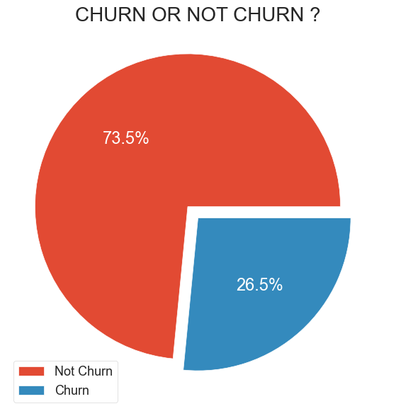

```python
plt.figure(figsize = (8,7))
plt.title('CHURN OR NOT CHURN ?', fontsize = 20)

labels = 'Not Churn', 'Churn'

plt.pie(df['Churn'].value_counts(), autopct = '%.1f%%',
        textprops = {'fontsize' : 17, 'color' : 'white'}, explode = (0.1,0))

plt.legend(labels, loc='lower left', fontsize = 13)

plt.show()
```

> After seeing above result, I started to lookup on the internet to see what considered a *'Good Balance'* on the Churn rate, and found out the answer on this web site : https://www.profitwell.com/blog/how-b2b-and-b2c-companies-solve-churn-for-different-customers

> And I quote : 'B2B and B2C companies see different churn rates, on average, because of the different types of customers that they serve and retain. A 2016 Zuora study cites the average churn rate is around 24% for B2B companies, and around 31% for B2C companies.'

> Therefore we can see that there are differences on what considered a *'Good Balance'* between Churn Rate within the B2B (Business to Business) and B2C (Business to Customer). Although the study conducted by Zuora were in 2016, but I think it's still relevant since our data was from 2018, and the year's gap isn't too much afar. Therefore, we can still apply this study's conclusion to our data. Furthermore as we can see clearly by their target market and other information within this data, we can safely concluded that this company is considered as B2C business model.

> According to the Zuora study above, we can see that the average churn rate of a B2C companies is around 31%, while in this dataset we have around 27% Churn rate. Then we could say that this company's churn rate is still considered as having a *'Good Balance'* of Churn and Retention rate as it's still below the average's churn rate of B2C companies.

> However if we look closely, we can see that when we consider only the amount of customers who churned we got 26.5% of total customers. But when we consider the Monthly Charges, we can get that about 30.5% of total revenue was 'lost' by number of these customers who had left, that is about 139,131 dollar out of total 456,117 dollar.

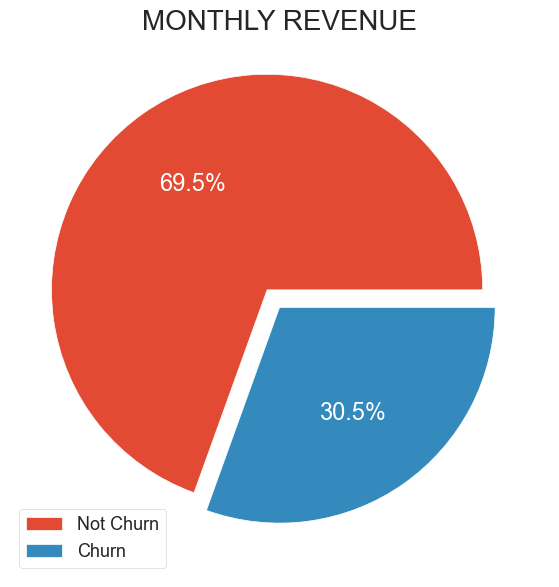

```python
plt.figure(figsize = (8,7))
plt.title('MONTHLY REVENUE', fontsize = 20)

labels = 'Not Churn', 'Churn'

plt.pie(df.groupby('Churn')['MonthlyCharges'].sum(), autopct = '%.1f%%',
        textprops = {'fontsize' : 17, 'color' : 'white'}, explode = (0.1,0))

plt.legend(labels, loc='lower left', fontsize = 13)

plt.show()
```

```python
print(round(df.groupby('Churn')['MonthlyCharges'].sum()))
```

```
Churn
No     316986.0
Yes    139131.0
Name: MonthlyCharges, dtype: float64
```

> Now we continue to explore our data. I'll start by dividing the features into two categories, separating them by their data types. Starting from the object data type, we categorize it as discrete features.

```python
df_cat = df.loc[:, df.dtypes == np.object].drop(['customerID'], axis = 1)
df_con = df.loc[:, df.dtypes != np.object]
```

```python
df_cat.head()
```

|  | Gender | SeniorCitizen | Partner | Dependents | PhoneService | MultipleLines | InternetService | OnlineSecurity | OnlineBackup | DeviceProtection | TechSupport | StreamingTV | StreamingMovies | Contract | PaperlessBilling | PaymentMethod | Churn |
| --- | --- | --- | --- | --- | --- | --- | --- | --- | --- | --- | --- | --- | --- | --- | --- | --- | --- |
| 0 | Female | No | Yes | No | No | No phone service | DSL | No | Yes | No | No | No | No | Month-to-month | Yes | Electronic check | No |
| 1 | Male | No | No | No | Yes | No | DSL | Yes | No | Yes | No | No | No | One year | No | Mailed check | No |
| 2 | Male | No | No | No | Yes | No | DSL | Yes | Yes | No | No | No | No | Month-to-month | Yes | Mailed check | Yes |
| 3 | Male | No | No | No | No | No phone service | DSL | Yes | No | Yes | Yes | No | No | One year | No | Bank transfer (automatic) | No |
| 4 | Female | No | No | No | Yes | No | Fiber optic | No | No | No | No | No | No | Month-to-month | Yes | Electronic check | Yes |

```python
df_con.head()
```

|  | Tenure | MonthlyCharges | TotalCharges |
| --- | --- | --- | --- |
| 0 | 1 | 29.85 | 29.85 |
| 1 | 34 | 56.95 | 1889.50 |
| 2 | 2 | 53.85 | 108.15 |
| 3 | 45 | 42.30 | 1840.75 |
| 4 | 2 | 70.70 | 151.65 |

### CATEGORICAL FEATURES

```python
# Cramers'v for categorical feature correlation

def cramersv(x, y):
    confusion_matrix = pd.crosstab(x,y)
    chi2 = ss.chi2_contingency(confusion_matrix)[0]
    n = confusion_matrix.sum().sum()
    phi2 = chi2/n
    r,k = confusion_matrix.shape
    phi2corr = max(0, phi2-((k-1)*(r-1))/(n-1))
    rcorr = r - ((r-1)**2)/(n-1)
    kcorr = k - ((k-1)**2)/(n-1)
    return np.sqrt(phi2corr/min((kcorr-1),(rcorr-1)))
```

```python
# Correlation between categorical features

corr = []
for i in df_cat.columns:
    matrix = []
    for j in df_cat.columns:
        matrix.append(cramersv(df_cat[i], df_cat[j]))
    corr.append(matrix)

corr_cat = pd.DataFrame(corr, index = df_cat.columns, columns = df_cat.columns)
```

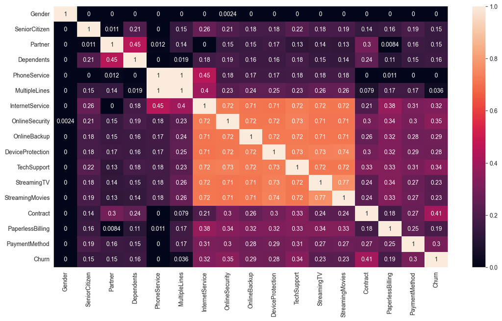

```python
plt.figure(figsize = (15,8))
sns.heatmap(corr_cat, annot = True)
plt.show()
```

> As we can see there are many features significantly correlated with each other - more than 0,7. Since I want to be more focused on target, I'll show only a couple of their correlation using `pd.crosstab()` below.

```python
pd.crosstab(df_cat['InternetService'], df_cat['OnlineSecurity'], normalize = True)
```

| OnlineSecurity InternetService | No | No internet service | Yes |
| --- | --- | --- | --- |
| DSL | 0.176203 | 0.000000 | 0.167542 |
| Fiber optic | 0.320460 | 0.000000 | 0.119125 |
| No | 0.000000 | 0.216669 | 0.000000 |

> About 32% of the total customer are not using Online Security while using Fiber Optic Internet Services. Most of the customer whom are using Online Security are choosing the DSL Internet Services, while the customer who neither using Online Security nor the Internet services are about 21%.

```python
pd.crosstab(df_cat['DeviceProtection'], df_cat['OnlineBackup'], normalize = True)
```

| OnlineBackup DeviceProtection | No | No internet service | Yes |
| --- | --- | --- | --- |
| No | 0.281698 | 0.000000 | 0.157745 |
| No internet service | 0.000000 | 0.216669 | 0.000000 |
| Yes | 0.156751 | 0.000000 | 0.187136 |

```python
pd.crosstab(df_cat['TechSupport'], df_cat['InternetService'], normalize = True)
```

| InternetService TechSupport | DSL | Fiber optic | No |
| --- | --- | --- | --- |
| No | 0.176487 | 0.316626 | 0.000000 |
| No internet service | 0.000000 | 0.000000 | 0.216669 |
| Yes | 0.167258 | 0.122959 | 0.000000 |

> Although most of the customer here are using Fiber Optic Internet Service, they still prefer not using Tech Support. Surprisingly, the one ended up sing Tech Support are from DSL Internet Services.

```python
pd.crosstab(df_cat['Churn'], df_cat['Contract'], normalize = True)
```

| Contract Churn | Month-to-month | One year | Two year |
| --- | --- | --- | --- |
| No | 0.315207 | 0.185574 | 0.233849 |
| Yes | 0.234985 | 0.023570 | 0.006815 |

> We can see that the churning customers are mainly not using One year and Two year contract. Maybe we can infer that most of the customer who are churning mainly having Month to month contract. Furthermore from crosstab below we can see that the churning customer are mainly not using Online Security.

```python
pd.crosstab(df_cat['Churn'], df_cat['OnlineSecurity'], normalize = True)
```

| OnlineSecurity Churn | No | No internet service | Yes |
| --- | --- | --- | --- |
| No | 0.289223 | 0.200625 | 0.244782 |
| Yes | 0.207440 | 0.016044 | 0.041886 |

> I think that's enough information for now. Next we'll explore the Gender, Senior Citizen, Partner and Dependent features as it contains *the demographic info* about customers. Then from there, we'll continue accordingly.

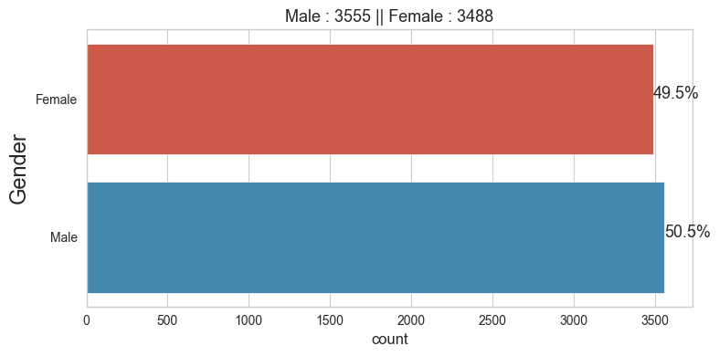

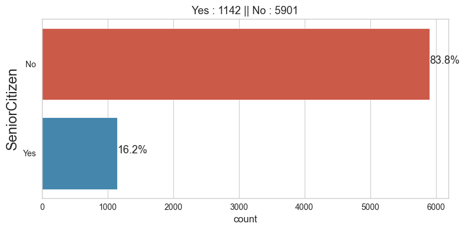

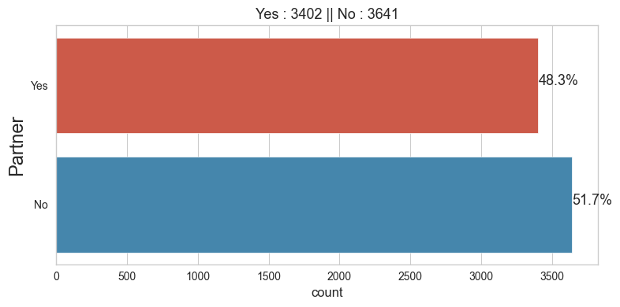

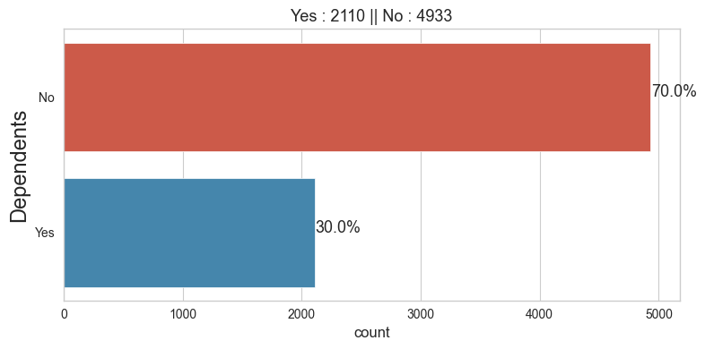

```python
for col in ('Gender', 'SeniorCitizen', 'Partner', 'Dependents'):
    plt.figure(figsize=(8,4))
    ax  = sns.countplot(y= col, data = df)

    total = len(df[col])
    for val in ax.patches:
        pct  = '{:.1f}%'.format(100 * val.get_width()/total)
        xpos = val.get_x() + val.get_width() +1.5
        ypos = val.get_y() + val.get_height() /2
        ax.annotate(pct, (xpos, ypos), fontsize = 13)

    yes  = df[col].value_counts()[1]
    no   = df[col].value_counts()[0]

    if col == 'Gender':
        plt.title(f'Male : {no} || Female : {yes}', fontsize = 13)
    else :
        plt.title(f'Yes : {yes} || No : {no}', fontsize = 13)

    plt.ylabel(col, fontsize = 17)
    plt.tight_layout()
    plt.show()
```

> From above plots, we can infer that although we have almost evenly matches number in both Male and Female in Gender features, but there are roughly only 16.2% of them identified as senior citizen, while the rest of it about 83.8% are not a senior citizen. While the definition of the senior citizen may vary accross the regions, but the lowest age I could find in the internet is 55 years (source : https://www.seniorliving.org/life/senior-citizen/).

> Let us assume that this is information is correct. Then this basically means that there are 83.8% of the customers are in the age of 54 or lower, which I think this is a valuable information for the company's, especially their marketing, as from this information they might find some interesting new approach to their customers.

> Moving on to Partner feature, we can see that there are 48.3% of total customers whom having a Partner, whereas the rest of them are having no Parter, might be 'single'. Yet interestingly if we see the Dependent features, there are only 30% of total customers or 2110 customers who are having Dependent status. According to this link : https://www.1040.com/tax-guide/taxes-for-families/who-can-you-claim/, dependancy status meaning that you are usually, but not always, having a child or other relative. Seems that we've gained so much information whithin these plot only.

> Let's continue to the next features below, it's about *the service types*.

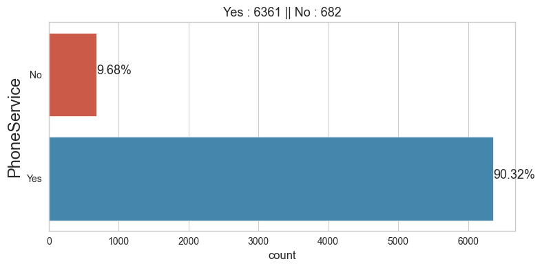

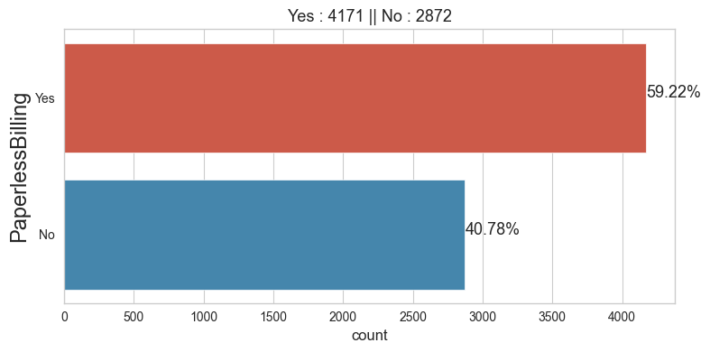

```python
for col in ('PhoneService', 'PaperlessBilling'):
    plt.figure(figsize=(8,4))
    ax  = sns.countplot(y= col, data = df)

    total = len(df[col])
    for val in ax.patches:
        pct  = '{:.2f}%'.format(100 * val.get_width()/total)
        xpos = val.get_x() + val.get_width() +1.5
        ypos = val.get_y() + val.get_height() /2
        ax.annotate(pct, (xpos, ypos), fontsize = 13)

    yes  = df[col].value_counts()[1]
    no   = df[col].value_counts()[0]

    plt.title(f'Yes : {no} || No : {yes}', fontsize = 13)

    plt.ylabel(col, fontsize = 17)
    plt.tight_layout()
    plt.show()
```

> From above plot, we can see that the majority of customers (90%) choose to have a Phone Service, interestingly there are still 40% customers whom not using the Paperless Billing, meaning that they might preffered using manual billing, what does it implies ? More on this we can see on plot below.

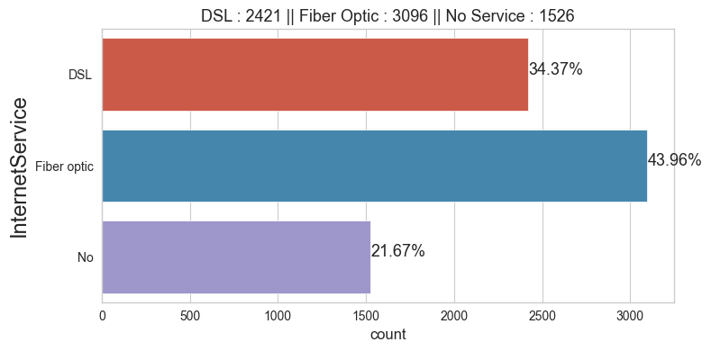

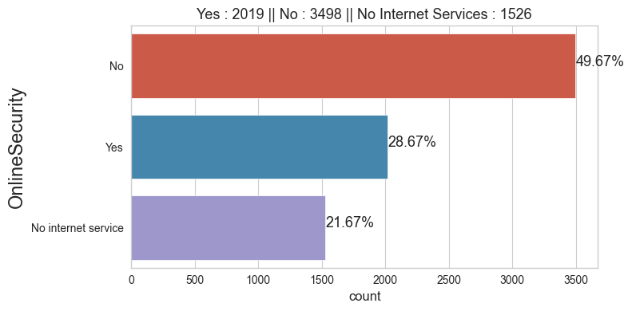

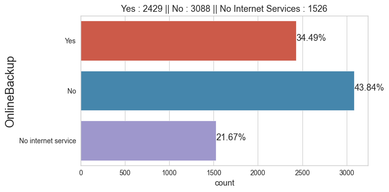

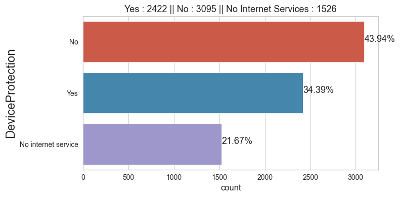

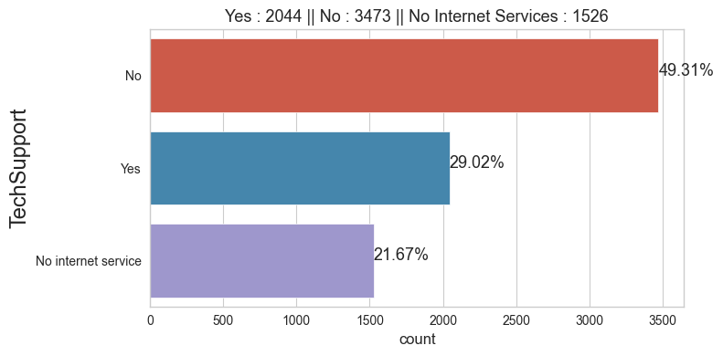

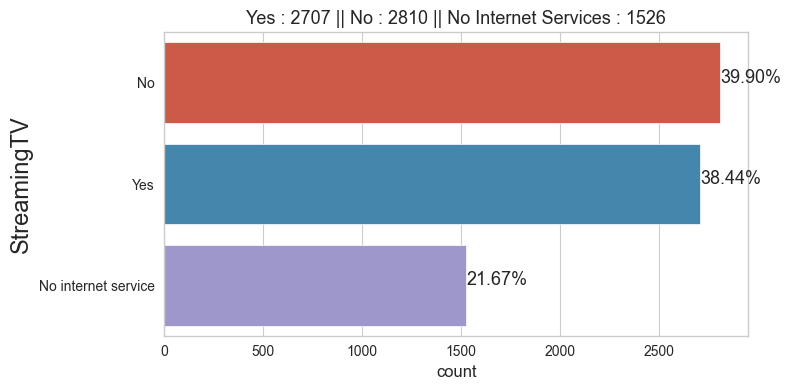

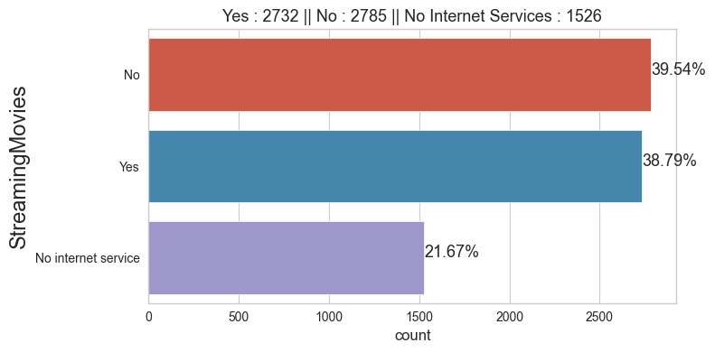

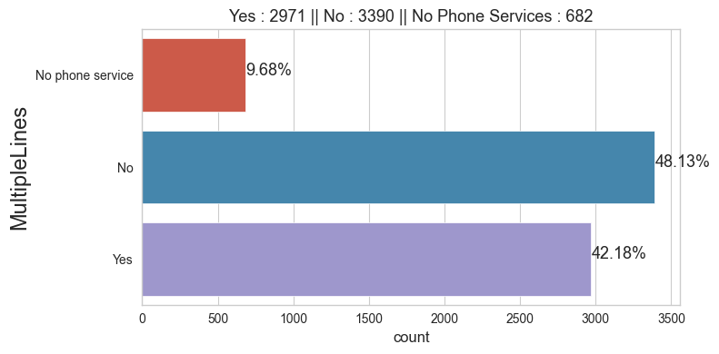

```python
for col in ('InternetService', 'OnlineSecurity', 'OnlineBackup', 'DeviceProtection', 'TechSupport',
            'StreamingTV', 'StreamingMovies', 'MultipleLines'):
    plt.figure(figsize = (8,4))
    ax  = sns.countplot(y= col, data = df)

    total = len(df[col])
    for val in ax.patches:
        pct = '{:.2f}%'.format(100 * val.get_width()/total)
        xpos = val.get_x() + val.get_width() +1.5
        ypos = val.get_y() + val.get_height() /2
        ax.annotate(pct, (xpos, ypos), fontsize = 13)

    yes = df[col].value_counts()[1]
    no  = df[col].value_counts()[0]
    nos = df[col].value_counts()[2]

    if col == 'MultipleLines':
        plt.title(f'Yes : {yes} || No : {no} || No Phone Services : {nos}', fontsize = 13)
    elif col == 'InternetService':
        plt.title(f'DSL : {yes} || Fiber Optic : {no} || No Service : {nos}', fontsize = 13)
    else:
        plt.title(f'Yes : {yes} || No : {no} || No Internet Services : {nos}', fontsize = 13)

    plt.ylabel(col, fontsize = 17)
    plt.tight_layout()
    plt.show()
```

> Further examining the plots above, first I'll start from the Multiple Lines features, from this we can see that there are almost 10% of all customer having no phone services in their area, while the rest who have phone services, splitted in two, there are 42% of customers who choose to have multiple lines and 48% not having multiple lines installed.

> Pretty interesting information, continuing on above plot, we see there are roughly 22% of the total customers on this dataset that not using the Internet services provided, while the rest of them (about 78%) are choosing to enable their services. Among them, there are 34% using Online Backup, 28% using Online Securities, 34% enabled the Device Protection, 29% enabled the Tech Support, 38% subscibed to tv streaming and movie streaming. The rest of them are having their internet services enabled, but choose not to enabled the add on services.

> For now let's continue to the next features, it's about customer's *account information*.

[figure not shown]

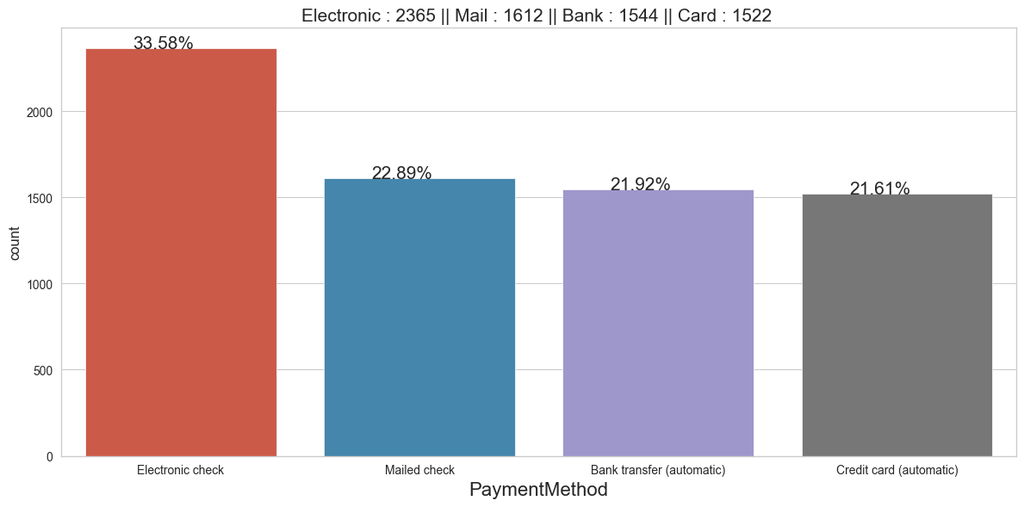

```python
for col in ('Contract', 'PaymentMethod'):
    plt.figure(figsize = (12,6))
    ax  = sns.countplot(x = col, data = df)

    total = len(df[col])
    for val in ax.patches:
        pct = '{:.2f}%'.format(100 * val.get_height()/total)
        xpos = val.get_x() +0.2
        ypos = val.get_height()
        ax.annotate(pct, (xpos, ypos), fontsize = 15)

    cat1 = df[col].value_counts()[0]
    cat2 = df[col].value_counts()[1]
    cat3 = df[col].value_counts()[2]
    cat4 = df['PaymentMethod'].value_counts()[3]

    if col == 'PaymentMethod':
        plt.title(f'Electronic : {cat1} || Mail : {cat2} || Bank : {cat3} || Card : {cat4} ', fontsize = 15)
    elif col == 'InternetService':
        plt.title(f'DSL : {cat2} || Fiber Optic : {cat1} || No Service : {cat3}', fontsize = 15)
    else :
        plt.title(f'Month to Month : {cat1} || One Year : {cat2} || Two Year : {cat3}', fontsize = 15)

    plt.xlabel(col, fontsize = 16)
    plt.tight_layout()
    plt.show()
```

> According to these article : https://www.profitwell.com/blog/why-annual-plans-are-crucial-for-reducing-your-churn.

> And I quote : "When setting up a pricing strategy, most companies go with the tried-and-true monthly plan because it allows for more rapid feedback on their product and their product market fit. It also creates less friction for new customers who are still unsure of their willingness to pay. For a new company, this is ideal because more customers mean more data to help fine tune your product."

> The staggering 55% of customers who choose the month to month contract in our Contract Type features, are maybe gravely dangerous to this company as I assume that they're still unsure and having no leverage in case when they're churning. On the other hand, there are 45% customers who already sure and probably loyal to this company. Now if we move to the Payment method, I pressumed that the customer whom using automatic method as their payment method are actually quite commited to this company.

### NUMERICAL FEATURES

> Let's start by examining the correlation using proper method. Therefore we need to check the normality as well as outliers in this section.

```python
# Goodness of fit test

def normal(df):

    stat = anderson(df)[0]
    cval = anderson(df)[1][2]
    if stat < cval :
        print('NORMALLY Distributed for ' + col + ' feature')
    else :
        print('NOT NORMALLY Distributed for ' + col + ' feature')
```

```python
for col in df_con :
    normal(df_con[col])
```

```
NOT NORMALLY Distributed for Tenure feature
NOT NORMALLY Distributed for MonthlyCharges feature
NOT NORMALLY Distributed for TotalCharges feature
```

> Since the data are not normally distributed, we're going to use *spearman correlation* method.

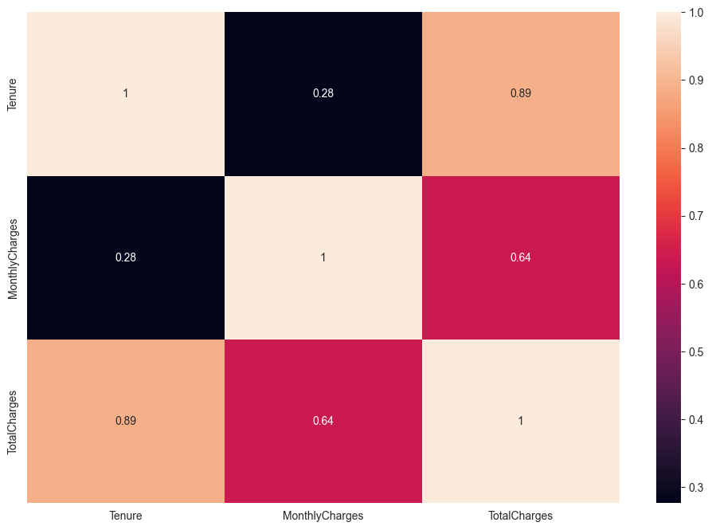

```python
plt.figure(figsize = (12,8))
sns.heatmap(df_con.corr('spearman'), annot = True)
plt.show()
```

> We can see that the Tenure features are significantly correlated with Total Charges. The Montly Charges obviously also correlated with Total Charges feature. We'll see the relationship using `pairplot()` below.

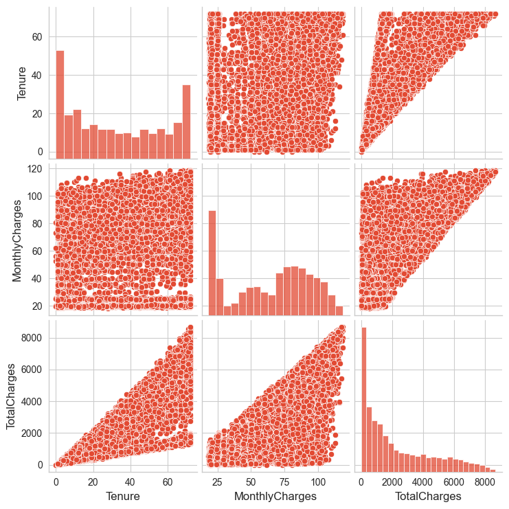

```python
sns.pairplot(df_con)
```

> From plot above alone, we kind of getting much information regarding this continous features. But let's continue the exploration anyway.

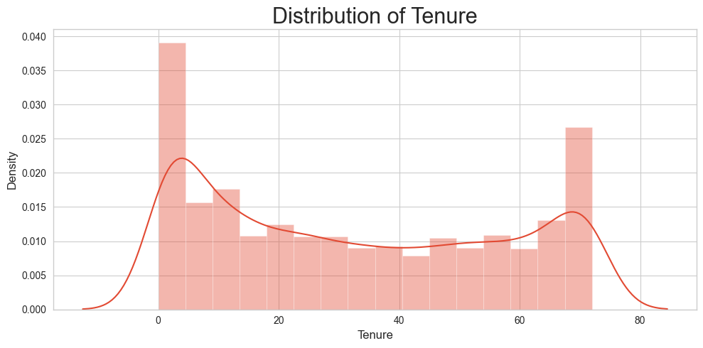

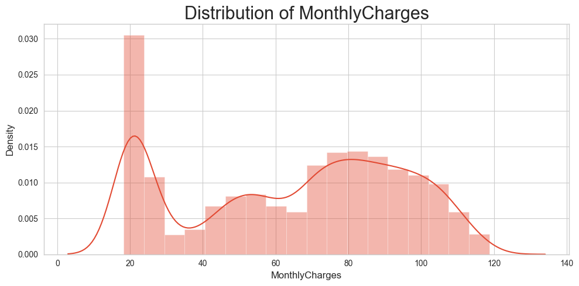

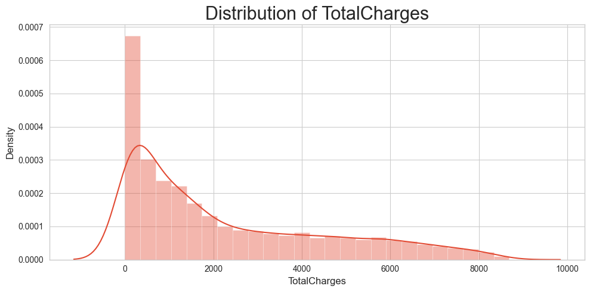

```python
for col in df_con :
    plt.figure(figsize = (10,5))

    sns.distplot(df[col])
    plt.xlabel(col, fontsize = 12)
    plt.title('Distribution of ' + col, fontsize = 22)

    plt.tight_layout()
    plt.show()
```

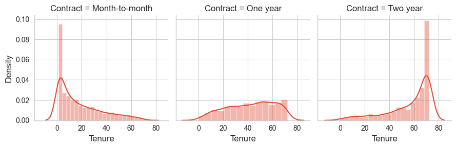

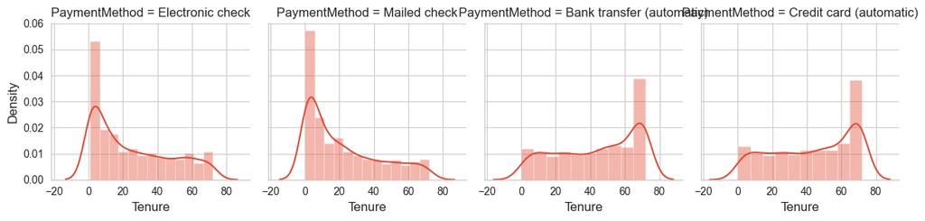

```python
for col in ('Contract', 'PaymentMethod'):
    sns.FacetGrid(df, col = col).map(sns.distplot, 'Tenure')
```

> From the plot above, we can see that the customers whom using Electronic and Mailed Check as their payment method tended to be a new customers, this indicated by their small tenures, while contrary the Bank Transfer and Credit Card are old customers or maybe their loyal one. In other word, we can infer from the pattern that maybe most of the new customers tended to use check method (either mailed or electronic) compared to loyal customer (people who have a bigger tenure) who are more likey to use automatic payment method.

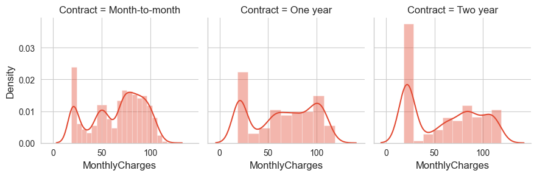

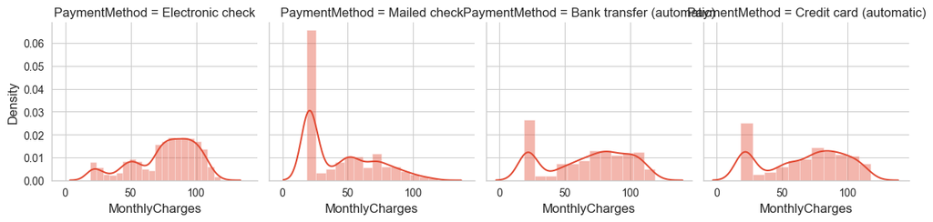

```python
for col in ('Contract', 'PaymentMethod'):
    sns.FacetGrid(df, col = col).map(sns.distplot, 'MonthlyCharges')
```

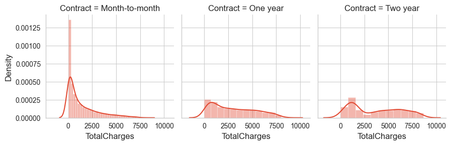

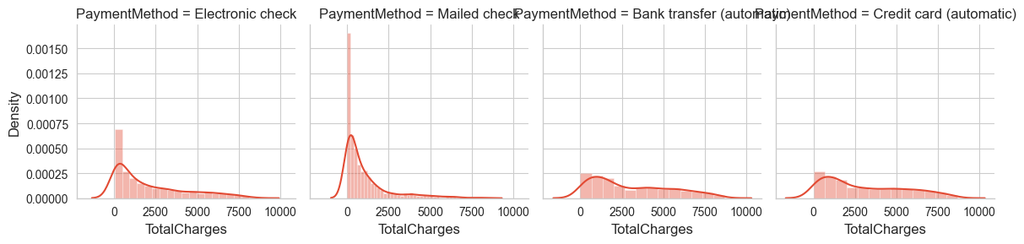

```python
for col in ('Contract', 'PaymentMethod'):
    sns.FacetGrid(df, col = col).map(sns.distplot, 'TotalCharges')
```